# code

**Reinforcement Learning Implementation for CartPole Game**

**Introduction** This report outlines the implementation, training, and evaluation of a Reinforcement Learning model using Deep Q-Networks (DQN) for the CartPole-v1 environment provided by OpenAI Gym. By applying appropriate force to the cart in either direction the aim is to train an agent to balance a pole on a cart. Game Selection

**CartPole Environment** • Environment: CartPole-v1 from OpenAI Gym • Objective: Ensure that the pole is positioned on the cart for as long as possible. • State Space: Continuous, consisting of four elements: cart position, cart velocity, pole angle, and pole angular velocity. • Action Space: Discrete, consisting of two actions: move the cart left or right.

**RL Implementation** Algorithm: Deep Q-Networks (DQN) Deep Q-Networks are used to approximate the Q-value function, which predicts the anticipated future rewards for an action taken in each state. This algorithm involves training a neural network to predict Q-values and using a replay buffer to store and record samples for training.

**Structure of Model** Q-network is a simple Three layers feedforward neural network: • Input Layer: Takes the state as input (4 features). • Hidden Layers: Two hidden layers with 24 neurons each and ReLU activation. • Output Layer: Outputs Q-values for each action (2 actions).

**Hyperparameters** • Gamma (Discount Factor): 0.99 • Epsilon (Exploration Probability): Starts at 1.0 and decays to 0.01 with a decay rate of 0.995 • Rate of Learning: 0.001 • Size of Batch: 32 • Size of Memory: 2000

**Training Process** 1. Initialize Environment: Set up CartPole-v1 environment. 2. Create Q-Networks: Define the Q-network and target network. 3. Compile Networks: Use Adam optimizer and mean squared error loss. 4. Replay Buffer: Store experiences for training. 5. Select Action: Choose an action based on epsilon-greedy policy. 6. Train Network: Sample a minibatch from replay buffer and update Q-values using Bellman equation. 7. Target Network Update: Periodically update the weights of target network with the Q-network weights. 8. Run Episodes: Train the model over multiple episodes and record the scores.

**Experimentation and Evaluation**

**Training Episodes** The agent was taught over 500 episodes. Through each episode, with the environment the agent interacted, selected actions based on the epsilon-greedy policy, and stored experiences in the replay buffer. The network was updated using a series of experiences sampled from the buffer.

**Results** Score: The score for each episode is based on the duration of the pole's balance before falling. Epsilon Decay: Epsilon began at 1.0 and decayed to 0.08 by the end of training, reducing the exploration rate. Average Reward: The average reward per episode over 500 episodes was roughly 13.8.

**Visualization** The training progress was observed using a plot illustrating the score per episode and the average reward provided in Figure1 in code section.

**Future Suggestions** 1. Enhance Model: Experiment with deeper networks or different architectures to enhance performance. 2. Hyperparameter Tuning: Improve hyperparameters such as rate of learning, size of Batch, and size of memory. 3. Advanced Techniques: Implement techniques such as Double DQN, Prioritized Experience Replay, and Dueling DQN for improved performance.

**Link to Github:** [text](https://github.com/Herr-Mahin/B143_AI-Studio)

**Code**

[output not shown]

[output cut: 5434 more lines]

```
1/1 ━━━━━━━━━━━━━━━━━━━━ 0s 25ms/step
1/1 ━━━━━━━━━━━━━━━━━━━━ 0s 35ms/step
1/1 ━━━━━━━━━━━━━━━━━━━━ 0s 54ms/step
Episode 499/500, Score: 9.0, Epsilon: 0.08
1/1 ━━━━━━━━━━━━━━━━━━━━ 0s 34ms/step
1/1 ━━━━━━━━━━━━━━━━━━━━ 0s 29ms/step
1/1 ━━━━━━━━━━━━━━━━━━━━ 0s 33ms/step
1/1 ━━━━━━━━━━━━━━━━━━━━ 0s 28ms/step
1/1 ━━━━━━━━━━━━━━━━━━━━ 0s 25ms/step
1/1 ━━━━━━━━━━━━━━━━━━━━ 0s 25ms/step
1/1 ━━━━━━━━━━━━━━━━━━━━ 0s 34ms/step
1/1 ━━━━━━━━━━━━━━━━━━━━ 0s 39ms/step
1/1 ━━━━━━━━━━━━━━━━━━━━ 0s 30ms/step
Episode 500/500, Score: 8.0, Epsilon: 0.08
Average Reward per Episode: 13.8
```

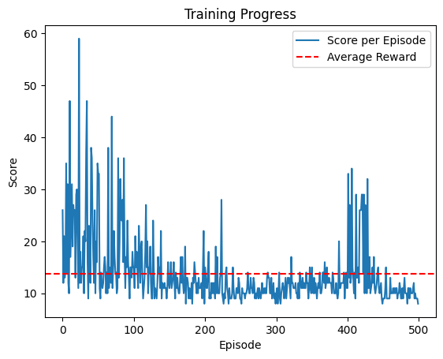

```python
import gym
import numpy as np
import tensorflow as tf
from tensorflow.keras import layers
import matplotlib.pyplot as plt
from collections import deque
import random

# Set up the CartPole environment
env = gym.make('CartPole-v1')

# Define the DQN model
def create_q_model(input_shape, action_space):
    model = tf.keras.Sequential()
    model.add(layers.Dense(24, input_shape=input_shape, activation='relu'))
    model.add(layers.Dense(24, activation='relu'))
    model.add(layers.Dense(action_space, activation='linear'))
    return model

# Define hyperparameters
gamma = 0.99  # Discount factor
epsilon = 1.0  # Exploration probability
epsilon_min = 0.01
epsilon_decay = 0.995
learning_rate = 0.001
batch_size = 32
memory_size = 2000

# Initialize models and memory
action_space = env.action_space.n
state_shape = env.observation_space.shape
model = create_q_model(state_shape, action_space)
target_model = create_q_model(state_shape, action_space)

# Compile the models
model.compile(optimizer=tf.keras.optimizers.Adam(learning_rate=learning_rate), loss='mse')
target_model.compile(optimizer=tf.keras.optimizers.Adam(learning_rate=learning_rate), loss='mse')

memory = deque(maxlen=memory_size)

# Function to select action
def select_action(state, epsilon):
    if np.random.rand() <= epsilon:
        return env.action_space.sample()
    q_values = model.predict(state)
    return np.argmax(q_values[0])

# Function to train the model
def train_model():
    if len(memory) < batch_size:
        return
    minibatch = random.sample(memory, batch_size)
    states, actions, rewards, next_states, dones = zip(*minibatch)
    states = np.vstack(states)
    next_states = np.vstack(next_states)
    targets = model.predict(states)
    target_next = target_model.predict(next_states)

    for i in range(batch_size):
        if dones[i]:
            targets[i][actions[i]] = rewards[i]
        else:
            targets[i][actions[i]] = rewards[i] + gamma * np.amax(target_next[i])

    model.fit(states, targets, epochs=1, verbose=0)

# Training loop
episodes = 500
scores = []
average_rewards = []

for e in range(episodes):
    state, _ = env.reset()
    state = np.reshape(state, [1, state_shape[0]])
    score = 0
    for time in range(500):
        action = select_action(state, epsilon)
        next_state, reward, done, _, _ = env.step(action)
        next_state = np.reshape(next_state, [1, state_shape[0]])
        memory.append((state, action, reward, next_state, done))
        state = next_state
        score += reward
        if done:
            break
    epsilon = max(epsilon_min, epsilon_decay * epsilon)
    train_model()
    target_model.set_weights(model.get_weights())
    scores.append(score)
    average_rewards.append(score)
    print(f"Episode {e+1}/{episodes}, Score: {score}, Epsilon: {epsilon:.2f}")

# Calculate average reward
average_reward = np.mean(average_rewards)
print("Average Reward per Episode:", average_reward)

# Plot results
plt.plot(scores, label='Score per Episode')
plt.axhline(y=average_reward, color='r', linestyle='--', label='Average Reward')
plt.xlabel('Episode')
plt.ylabel('Score')
plt.legend()
plt.title('Training Progress')
plt.show()
```